# State MSM Profile: **Nebraska**

### Background & Methods

In 2015-2016, researchers at Emory University partnered with colleagues at the Centers for Disease Control and Prevention (CDC) to develop methods to estimate the number of men who have sex with men (MSM) residing in each county in the United States. Using population and housing data from the [American Community Survey](https://www.census.gov/programs-surveys/acs/) and estimates from two peer-reviewed publications ([Oster et al., 2015](http://www.ncbi.nlm.nih.gov/pubmed/26115985) & [Purcell et al., 2012](http://www.ncbi.nlm.nih.gov/pubmed/23049658)), they derived an indirect estimate of MSM population sizes that took into account both the urbanicity of the county as well as its density of households with a male householder and a male same-sex partner.

The full methodology is published in the *Journal of Medical Internet Research - Public Health and Surveillance*:

> [Grey JA, Bernstein KT, Sullivan PS, Purcell DW, Chesson HW, Gift TL, Rosenberg ES. Estimating the population sizes of men who have sex with men in US states and counties using data from the American Community Survey. JMIR Public Health Surveill 2016;2(1):e14. DOI: 10.2196/publichealth.5365](http://publichealth.jmir.org/2016/1/e14/)

### Overview of MSM in Nebraska

An estimated **13,198** men who have sex with men (MSM) resided in Nebraska in 2013, representing 0.3% of the 4,503,084 MSM in the United States. Of the 678,518 adult men of Nebraska, 1.9% had had sex with another man in the past 5 years, which was less than the overall percentage of adult men in the United States who were MSM (3.9%).

Most MSM in Nebraska resided in counties within medium or small metropolitan areas (73.9%). No MSM in Nebraska resided in a large metropolitan area.

##### **Percentage of MSM by urbanicity, United States and Nebraska, 2013**

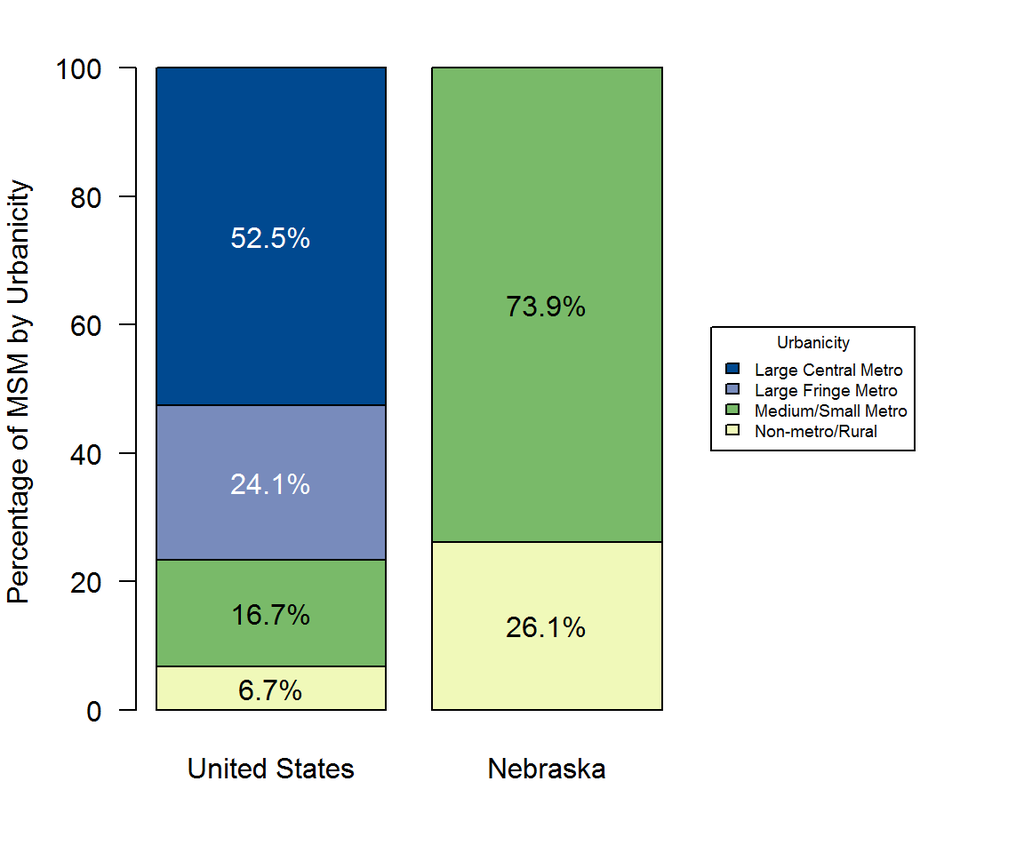

### MSM in Nebraska Counties

Among counties or county-equivalent areas in Nebraska, Douglas County had the largest population of MSM at 5,397, representing 40.9% of all MSM in the state. Sioux County had the highest percentage of MSM among adult men in Nebraska at 9.0%. This was greater than the percentage for Nebraska as a whole, which was 1.9% of adult men.

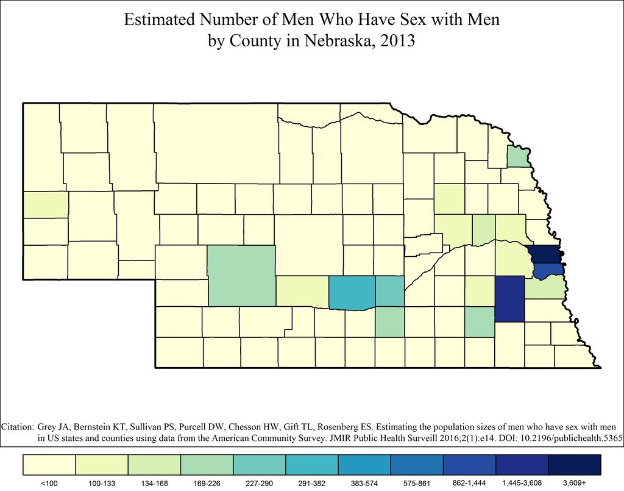

Note: Range cutpoints for the map are based on the distribution of MSM among all counties in the United States.

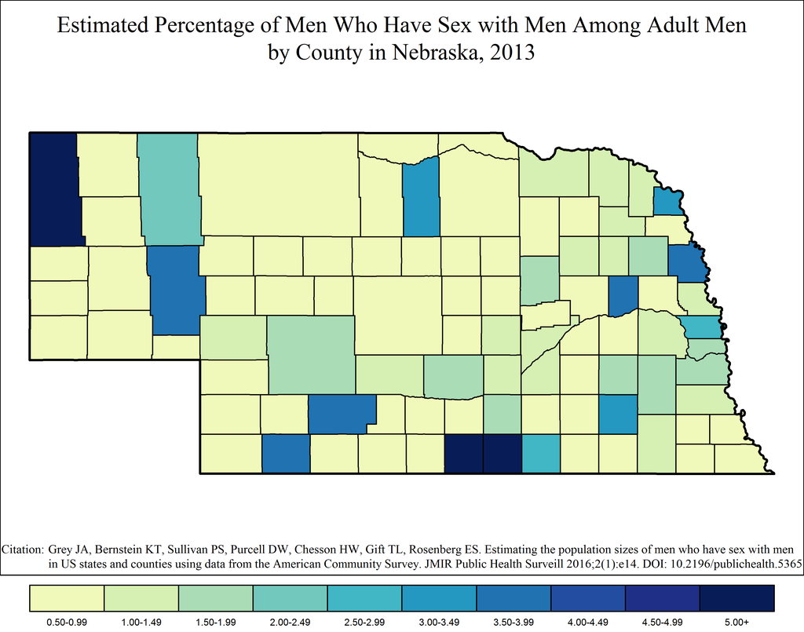

### MSM in Nebraska Metropolitan Statistical Areas

#### Omaha-Council Bluffs Metropolitan Statistical Area

The Omaha-Council Bluffs MSA overlaps two states: Iowa and Nebraska. The Nebraska portion of the MSA had the largest metropolitan population of MSM in Nebraska at 6,814, or 51.6% of all MSM in the state and 85.5% of the 7,971 MSM in the MSA. Of the 270,274 adult men in the Nebraska part of Omaha-Council Bluffs, an estimated 2.5% were MSM. This was equal to the percentage of MSM among adult men in the MSA as a whole, which was 2.5% of adult men (7,971 out of 315,494).

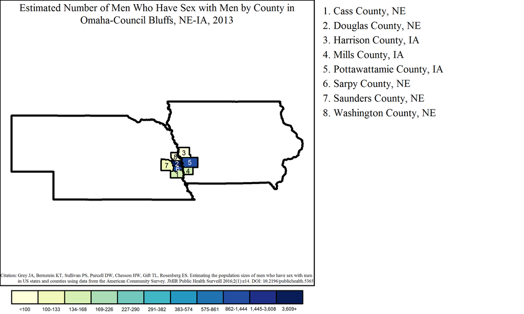

Note: Range cutpoints for the map are based on the distribution of MSM among all counties in the United States.

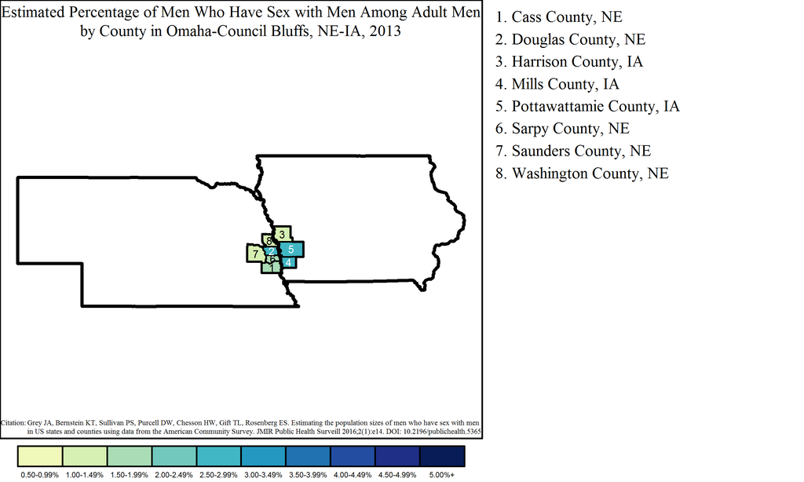

#### Lincoln Metropolitan Statistical Area

The Lincoln MSA had a population of 2,312 MSM, or 17.5% of all MSM in Nebraska. Of the 117,609 adult men in Lincoln, an estimated 2.0% were MSM.

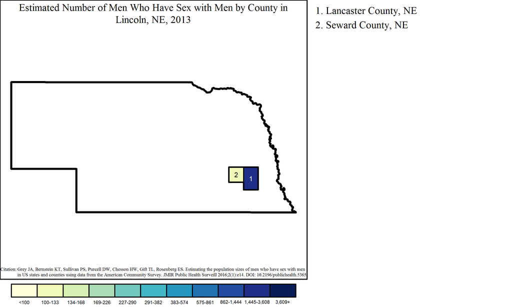

Note: Range cutpoints for the map are based on the distribution of MSM among all counties in the United States.

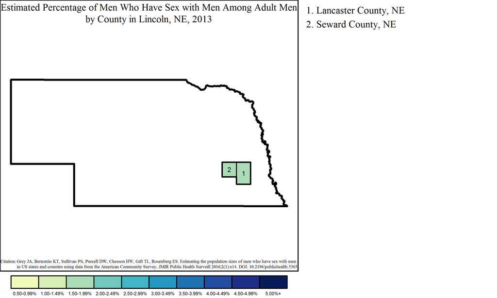

#### Grand Island Metropolitan Statistical Area

The Grand Island MSA had a population of 382 MSM, or 2.9% of all MSM in Nebraska. Of the 30,208 adult men in Grand Island, an estimated 1.3% were MSM.

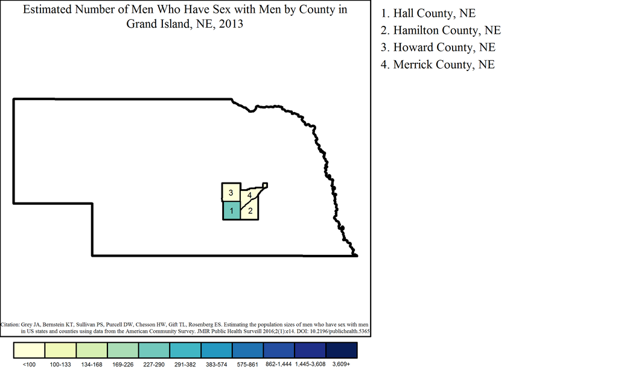

Note: Range cutpoints for the map are based on the distribution of MSM among all counties in the United States.

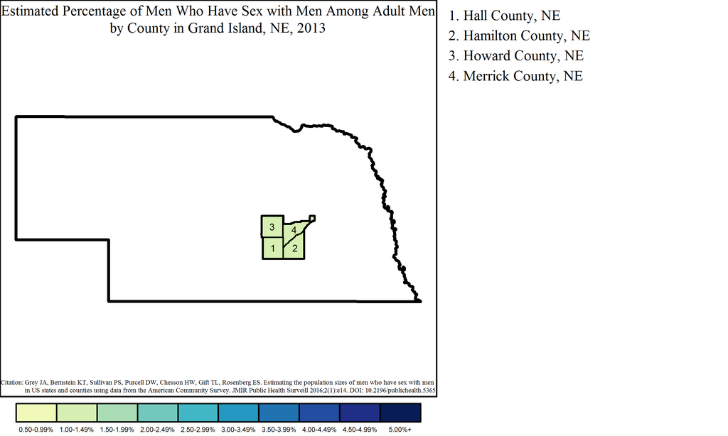

#### Sioux City Metropolitan Statistical Area

The Sioux City MSA overlaps three states: Iowa, Nebraska and South Dakota. The Nebraska portion of the MSA had 248 MSM, or 1.9% of all MSM in the state and 25.6% of the 967 MSM in the MSA. Of 9,386 adult men in the Nebraska part of Sioux City, 2.6% were MSM. This was greater than the overall percentage of MSM among adult men in the MSA, which was 1.6% of adult men (967 out of 60,459).

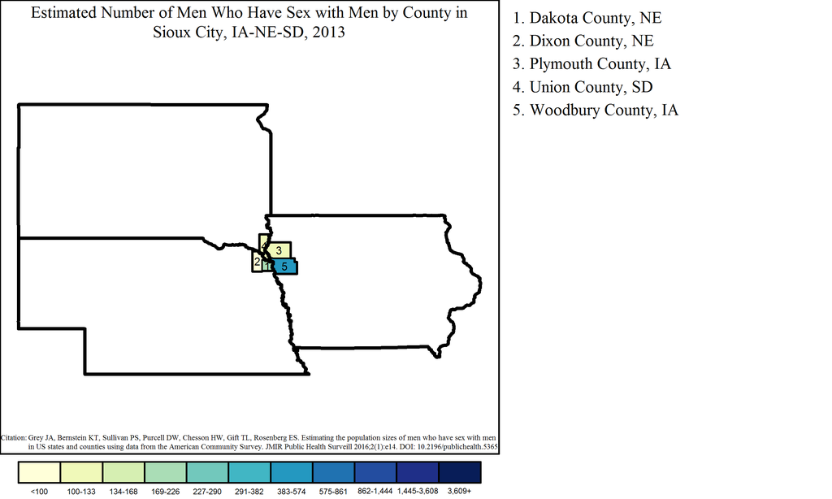

Note: Range cutpoints for the map are based on the distribution of MSM among all counties in the United States.

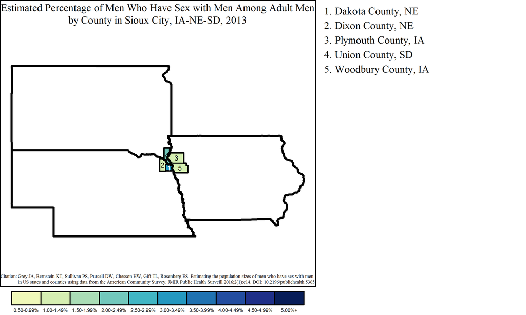